# Assignment 10: Predictive Modeling - Part 1

*How to do it?*:

- Open the Rmarkdown file of this assignment (link) in Rstudio.
- Right under each **question**, insert a code chunk (you can use the hotkey `Ctrl + Alt + I` to add a code chunk) and code the solution for the question.
- `Knit` the rmarkdown file (hotkey: `Ctrl + Alt + K`) to export an html.
- Publish the html file to your Githiub Page.

*Submission*: Submit the link on Github of the assignment to Canvas

1. Use the `Adult Census Income` dataset. We will predict the income (whether or not it is more than 50k or not) of an adult. Import the dataset. Partition the data into 80% training and 20% testing.

```r
library(dplyr)
library(tidyr)

census <- read.csv("C:/Users/student/Downloads/adult_census_missing.csv")

census <- census %>%
  select(-workclass, -race, -marital.status, -education,
         -occupation, -relationship, -native.country) %>%
  rename(target = income)

census$age <- as.numeric(census$age)
mean_age <- mean(census$age, na.rm = TRUE)
census$age <- replace_na(census$age, mean_age)


census <- drop_na(census)


census <- census %>%
  mutate(
    target = as.factor(target),
    sex = as.factor(sex),
    education.num = as.factor(education.num)
  )


set.seed(123)
idx <- unlist(
  lapply(split(seq_len(nrow(census)), census$target),
         function(rows) sample(rows, size = floor(0.8 * length(rows))))
)

census_train <- census[idx, ]
census_test  <- census[-idx, ]
```

2. Practice Decision Tree. Do the follows:
- Use `rpart` package, create a decision tree with maximum depth of 3.
- Calculate the accuracy of the model on the testing data. Notice that the positive outcome here is not `1` but `>50K` or `<50K`.
- Plot the tree
- Plot the variable importance by the tree

```r
library(rpart)
library(rpart.plot)

tree_model <- rpart(
  target ~ .,
  data = census_train,
  method = "class",
  control = rpart.control(maxdepth = 3)
)

predictions <- predict(tree_model, newdata = census_test, type = "class")
accuracy <- mean(predictions == census_test$target)
accuracy
```

```
## [1] 0.7994164
```

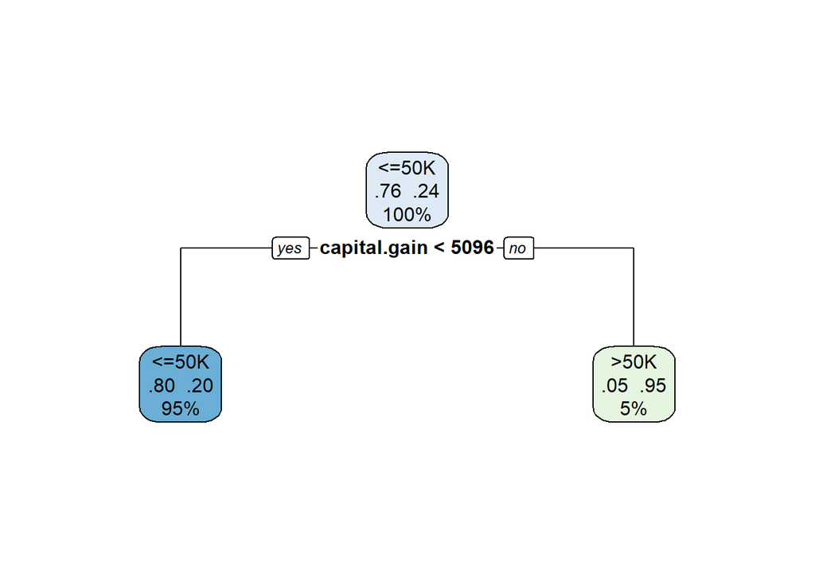

```r
rpart.plot(tree_model, type = 2, extra = 104, fallen.leaves = TRUE)
```

```r
varImp <- tree_model$variable.importance
varImp
```

```
## capital.gain
##     1354.282
```

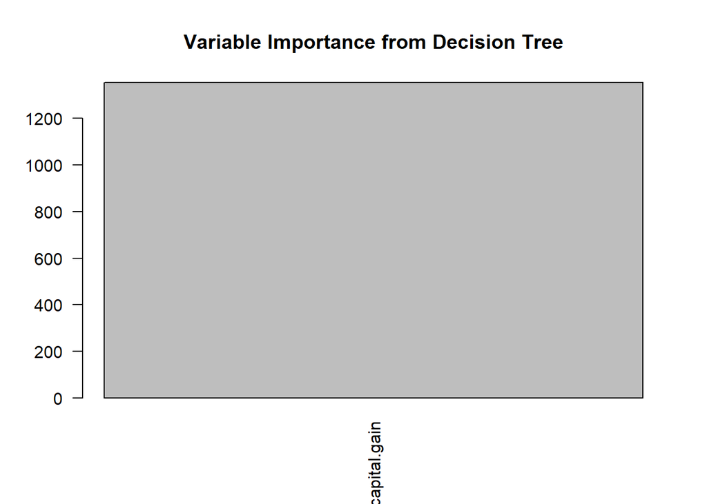

```r
barplot(varImp, main = "Variable Importance from Decision Tree", las = 2)
```

3. Create 3 more trees and compare the testing accuracy of these trees, which tree give the highest testing accuracy.

```r
tree2 <- rpart(target ~ ., data = census_train, method = "class",
               control = rpart.control(maxdepth = 5))
pred2 <- predict(tree2, newdata = census_test, type = "class")
acc2 <- mean(pred2 == census_test$target)

tree3 <- rpart(target ~ ., data = census_train, method = "class",
               control = rpart.control(maxdepth = 7))
pred3 <- predict(tree3, newdata = census_test, type = "class")
acc3 <- mean(pred3 == census_test$target)

tree4 <- rpart(target ~ ., data = census_train, method = "class")
pred4 <- predict(tree4, newdata = census_test, type = "class")
acc4 <- mean(pred4 == census_test$target)

accuracy_table_tree <- data.frame(
  Model = c("Tree1 (maxdepth=3)", "Tree2 (maxdepth=5)",
            "Tree3 (maxdepth=7)", "Tree4 (default)"),
  Accuracy = c(accuracy, acc2, acc3, acc4)
)

accuracy_table_tree
```

```
##                Model  Accuracy
## 1 Tree1 (maxdepth=3) 0.7994164
## 2 Tree2 (maxdepth=5) 0.8261404
## 3 Tree3 (maxdepth=7) 0.8261404
## 4    Tree4 (default) 0.8261404
```

```r
best_tree <- accuracy_table_tree[which.max(accuracy_table_tree$Accuracy), ]
best_tree
```

```
##                Model  Accuracy
## 2 Tree2 (maxdepth=5) 0.8261404
```

4. Practice Random Forest. Do the follows:
- Use `randomForest` package, create a random forest of 1000 trees.
- Calculate the accuracy of the model on the testing data.
- Plot the variable importance by the forest

```r
library(randomForest)

set.seed(123)
rf1 <- randomForest(
  target ~ .,
  data = census_train,
  ntree = 1000,
  importance = TRUE
)

rf_pred1 <- predict(rf1, newdata = census_test)
rf_acc1 <- mean(rf_pred1 == census_test$target)
rf_acc1
```

```
## [1] 0.847796
```

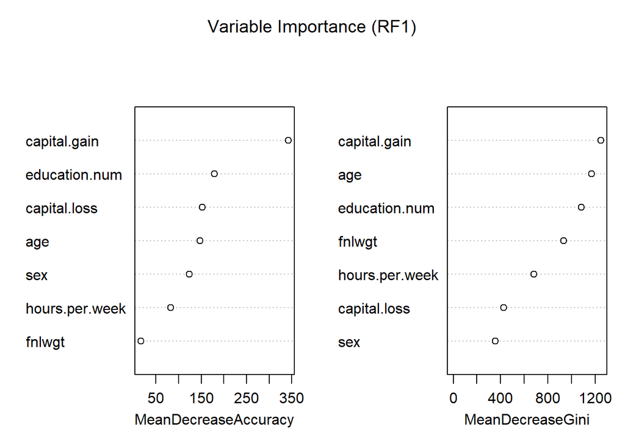

```r
varImpPlot(rf1, main = "Variable Importance (RF1)")
```

5. Create 3 more forests and compare the testing accuracy of these forests, which forest give the highest testing accuracy.

```r
library(randomForest)

set.seed(123)

rf1 <- randomForest(
  target ~ .,
  data = census_train,
  ntree = 1000,
  importance = TRUE
)
pred1 <- predict(rf1, newdata = census_test)
acc1_rf <- mean(pred1 == census_test$target)

rf2 <- randomForest(
  target ~ .,
  data = census_train,
  ntree = 500,
  importance = TRUE
)
pred2 <- predict(rf2, newdata = census_test)
acc2_rf <- mean(pred2 == census_test$target)

rf3 <- randomForest(
  target ~ .,
  data = census_train,
  ntree = 1500,
  importance = TRUE
)
pred3 <- predict(rf3, newdata = census_test)
acc3_rf <- mean(pred3 == census_test$target)

rf4 <- randomForest(
  target ~ .,
  data = census_train,
  ntree = 1000,
  mtry = 5,
  importance = TRUE
)
pred4 <- predict(rf4, newdata = census_test)
acc4_rf <- mean(pred4 == census_test$target)

accuracy_table <- data.frame(
  Forest = c(
    "RF1 (ntree=1000)",
    "RF2 (ntree=500)",
    "RF3 (ntree=1500)",
    "RF4 (ntree=1000, mtry=5)"
  ),
  Accuracy = c(acc1_rf, acc2_rf, acc3_rf, acc4_rf)
)

accuracy_table
```

```
##                     Forest  Accuracy
## 1         RF1 (ntree=1000) 0.8477960
## 2          RF2 (ntree=500) 0.8473353
## 3         RF3 (ntree=1500) 0.8481032
## 4 RF4 (ntree=1000, mtry=5) 0.8259868
```

```r
best_forest <- accuracy_table[which.max(accuracy_table$Accuracy), ]
best_forest
```

```
##             Forest  Accuracy
## 3 RF3 (ntree=1500) 0.8481032
```

6. What is the best model (in term of testing accuracy) among all models (including trees and forests) you have trained?

```r
all_models <- data.frame(
  Model = c(
    "Tree1 (depth=3)",
    "Tree2 (depth=5)",
    "Tree3 (depth=7)",
    "Tree4 (default)",
    "RF1",
    "RF2",
    "RF3",
    "RF4"
  ),
  Accuracy = c(
    accuracy,
    acc2,
    acc3,
    acc4,
    acc1_rf,
    acc2_rf,
    acc3_rf,
    acc4_rf
  )
)

all_models
```

```
##             Model  Accuracy
## 1 Tree1 (depth=3) 0.7994164
## 2 Tree2 (depth=5) 0.8261404
## 3 Tree3 (depth=7) 0.8261404
## 4 Tree4 (default) 0.8261404
## 5             RF1 0.8477960
## 6             RF2 0.8473353
## 7             RF3 0.8481032
## 8             RF4 0.8259868
```

```r
best_model <- all_models[which.max(all_models$Accuracy), ]
best_model
```

```
##   Model  Accuracy
## 7   RF3 0.8481032
```